# Predicting Baseball Games Against Gambling Lines

Robert Barris, Shivam Patel

5/18/2019

Important: The information used here was obtained free of charge from and is copyrighted by Retrosheet. Interested parties may contact Retrosheet at “www.retrosheet.org”.

Sources:

https://www.retrosheet.org/gamelogs/index.html

Libraries

The purpose of our final project is to determine if we can predict the outcome of a baseball game, by using data from recent games that the teams playing have produced. We will see if our predictions are sound enough to go with or against the Money Line. A Money Line bet is much one of the simplest bests you can place on a team. The bet placed on a team is whether that team will win the game. This differs from a spread as that requires that one team will win or lose by a specific number of runs, points or goals, depending on the sport, of course. If the Money Line is negative that is the amount that you would have to bet in order to win $100, and if the number is positive that is how much you would win on a $100 bet. Money Lines do not require that you bet that specific amount, but it would use the ratio of what you bet to your expected winnings. Given any baseball game, one team will always have a positive Money Line and one team will always have a negative Money Line. This indicates which team is favored for that particular game.

For the purpose of this project, we will assess these teams using specifically their last ten games, and a variety of statistics for those games, including but not limited to run scored and allowed, who pitched through the games and who started, where each game was, who they played against, etc. We will then create a regression to see if this data has any correlation to the success of the team with respect to the provided Money Line. This information will tell us whether it is a good idea to bet on a particular team given the specific Money Line and the likelihood of success for that team. We hope to be able to evaluate the Money Line and create a high probability that we will correctly predict the outcome of the games. Of course, this not always have a one hundred percent success rate, but our goal is be able to maximize profits by utilizing data from the teams recent games.

```r
csv_file <- "~/Desktop/CMSC320/FinalProject/BBData.csv"
bdata <- read_csv(csv_file)
colnames(bdata)[3] <- c("VisitingTeam")
colnames(bdata)[6] <- c("HomeTeam")
colnames(bdata)[5] <- c("VTGameNumber")
colnames(bdata)[8] <- c("HTGameNumber")
colnames(bdata)[9] <- c("VTScore")
colnames(bdata)[10] <- c("HTScore")
colnames(bdata)[12] <- c("ParkID")
colnames(bdata)[13] <- c("VTPitchersUsed")
colnames(bdata)[14] <- c("VTIndivEarnedRuns")
colnames(bdata)[15] <- c("VTTeamEarnedRuns")
colnames(bdata)[16] <- c("HTPitchersUsed")
colnames(bdata)[17] <- c("HTIndivEarnedRuns")
colnames(bdata)[18] <- c("HTTeamEarnedRuns")
colnames(bdata)[19] <- c("VTStartingPitcherID")
colnames(bdata)[20] <- c("VTStartingPitcherName")
colnames(bdata)[21] <- c("HTStartingPitcherID")
colnames(bdata)[22] <- c("HTStartingPitcherName")
colnames(bdata)[23] <- c("FullData")
bdata <- mutate(bdata, WinningTeam = ifelse( bdata$VTScore<  bdata$HTScore, bdata$HomeTeam, bdata$VisitingTeam))
bdata <- mutate(bdata, HomeWin = ifelse(bdata$WinningTeam == bdata$HomeTeam, 1, 0))
bdata <- mutate(bdata, VTWin = ifelse(bdata$WinningTeam == bdata$HomeTeam, 1, 0))
away <- data.frame(Date = bdata$Date, Team = bdata$VisitingTeam, Game = bdata$VTGameNumber, Runs = bdata$VTScore, RunsAllowed = bdata$HTScore, Win = bdata$VTWin, stringsAsFactors=FALSE)
home <- data.frame(Date = bdata$Date, Team = bdata$HomeTeam, Game = bdata$HTGameNumber, Runs = bdata$HTScore, RunsAllowed = bdata$VTScore, Win = bdata$HomeWin, stringsAsFactors=FALSE)
goodData <- rbind(away,home)
odds <- "~/Desktop/CMSC320/FinalProject/2018odds.csv"
oddsdf <- read_csv(odds)
oddsdf$Date <- gsub("(^\\d{1})(\\d{2})","\\1/\\2/18", oddsdf$Date)
wanted_data <- data.frame(Date = oddsdf$Date, Team = oddsdf$Team, Pitcher = oddsdf$Pitcher, MoneyLine = oddsdf$Open, OU = oddsdf$`Open OU`, Spread = oddsdf$RL)
final <- merge(wanted_data, goodData, by=c("Date", "Team"))
final <- final %>%
  group_by(Team) %>%
mutate(lastTenMRA = rollsumr(RunsAllowed, k = 10, fill = NA)/10) %>%
  mutate(lastTenMR = rollsumr(Runs, k = 10, fill = NA)/10) %>%
  arrange(Game)
final <- unique(final[,1:12])
```

https://www.sportsbookreviewsonline.com/scoresoddsarchives/mlb/mlboddsarchives.htm

Now that we have enough data, we want to find the most predictive variables on whether a team will win or lose a game not yet played. The first step is to visualize and run regressions on the variables.

RAG - Runs Allowed Per Game Quality Starts - Starting pitcher allowed 3 or fewer than earned runs and pitched 6 or more innings

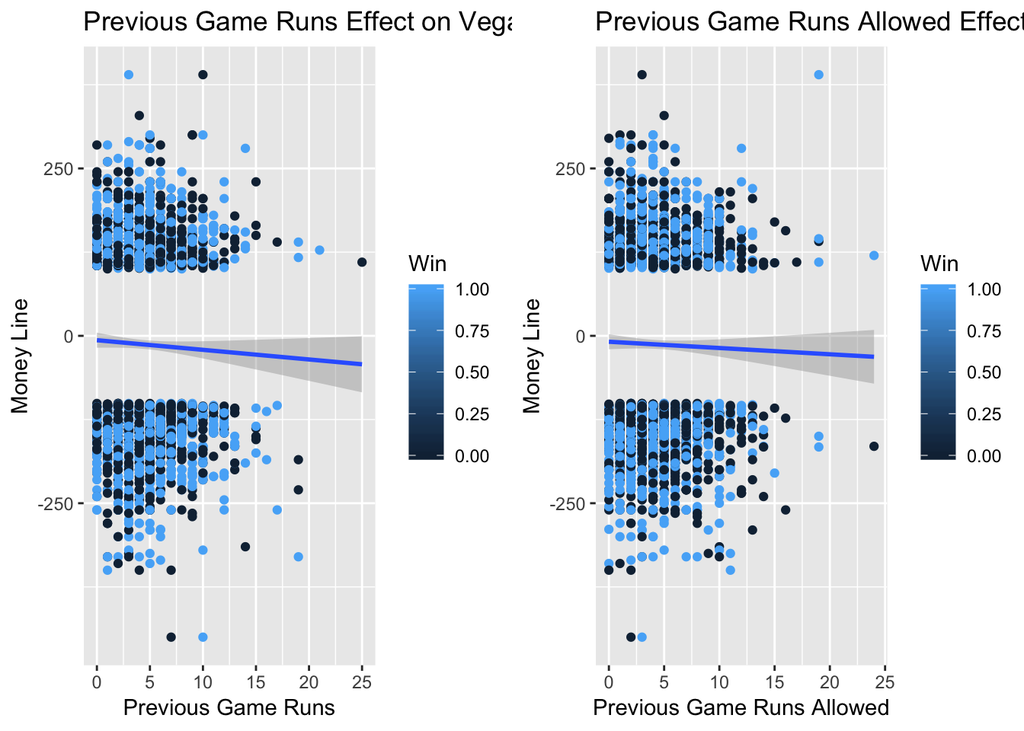

```r
p2<- final %>%
  group_by(Team)%>%
  ggplot(aes(x=lag(RunsAllowed), y = MoneyLine, color = Win)) +
    geom_point() +
    geom_smooth(method=lm) +
  labs(title="Previous Game Runs Allowed Effect on Vegas Money Line",
         x = "Previous Game Runs Allowed",
         y = "Money Line")
p1 <- final %>%
  group_by(Team)%>%
  ggplot(aes(x=lag(Runs), y = MoneyLine, color = Win)) +
    geom_point() +
    geom_smooth(method=lm) +
  labs(title="Previous Game Runs Effect on Vegas Money Line",
         x = "Previous Game Runs",
         y = "Money Line")
grid.arrange(p1,p2, ncol = 2)
```

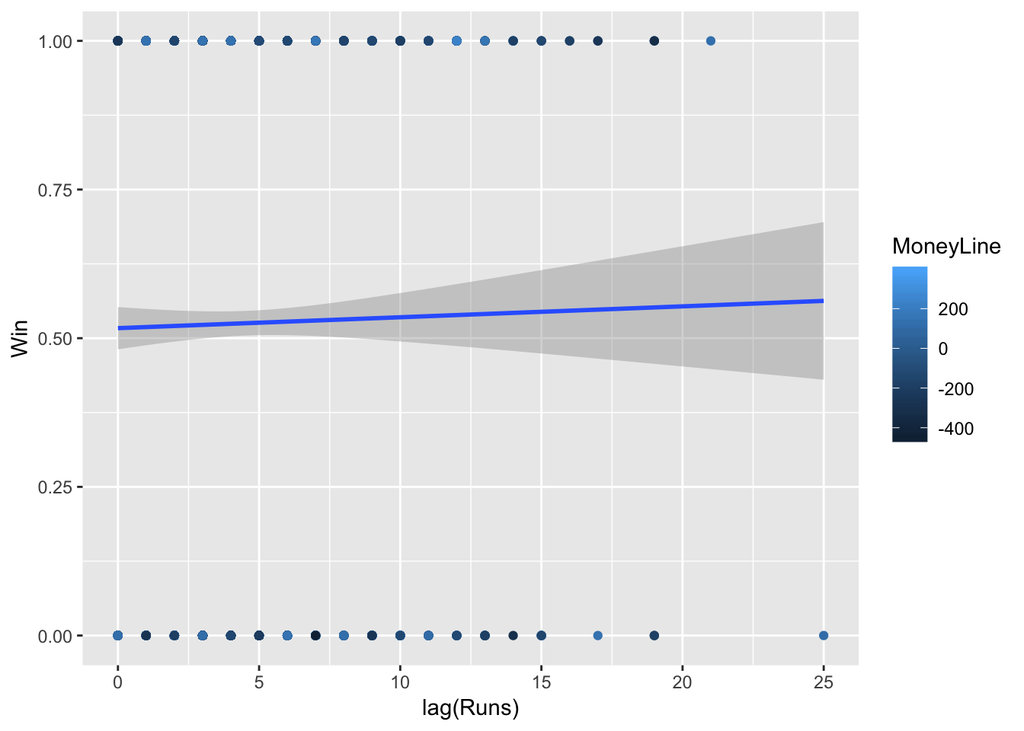

```r
final %>%
  group_by(Team)%>%
  ggplot(aes(x=lag(Runs), y = Win, color = MoneyLine)) +
    geom_point() +
    geom_smooth(method=lm)
```

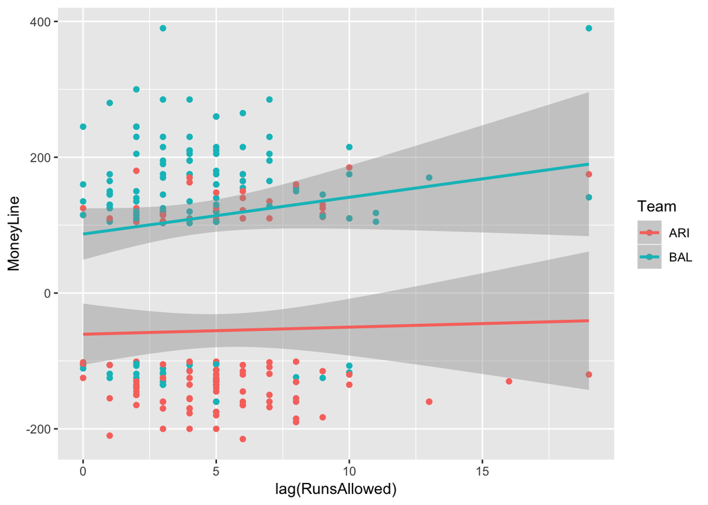

```r
plot2 <- final %>%
filter(Team == "ARI" || Team == "BAL")%>%
  ggplot(aes(x=MoneyLine, y = Win, color = Team)) +
    geom_point() +
    geom_smooth(method=lm)
plot1 <-final %>%
  filter(Team == "ARI" || Team == "BAL")%>%
  ggplot(aes(x=lastTenMRA, y = Win, color = Team)) +
    geom_point() +
    geom_smooth(method=lm)
plot3 <-final %>%
  filter(Team == "ARI" || Team == "BAL")%>%
  ggplot(aes(x=lastTenMR, y = Win, color = Team)) +
    geom_point() +
    geom_smooth(method=lm)
final %>%
  filter(Team == "ARI" || Team == "BAL")%>%
  ggplot(aes(x=lag(RunsAllowed), y = MoneyLine, color = Team)) +
    geom_point() +
    geom_smooth(method=lm)
```

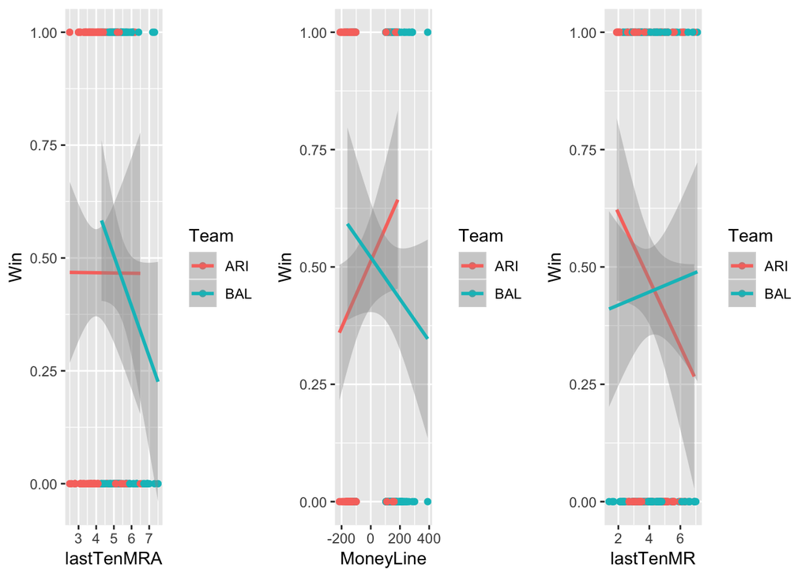

```r
grid.arrange(plot1, plot2, plot3, ncol=3)
```

These plots include data on previous game runs allowed and scored against the money line for those games. For this we look at two teams in particular. We will look at the Arizona Diamondbacks and the Baltimore Orioles. We plot these two teams to show how their number of wins correlate to their Money Lines, last ten games, and how their Money Line compares to their number of runs allowed. This information will be critical to see how the success of a team, particularly these two, has an effect on their Money Line for their games.

```r
final <- final %>%
  group_by(Team)
  mulr <- lm(formula = final$Win ~ lag(Runs)*lag(RunsAllowed), data = final)
  mulrtidy <- mulr %>% tidy()
mulrtidy
```

```
## # A tibble: 4 x 5
##   term                       estimate std.error statistic  p.value
##   <chr>                         <dbl>     <dbl>     <dbl>    <dbl>
## 1 (Intercept)                 0.499    0.0309      16.2   1.16e-55
## 2 lag(Runs)                   0.0106   0.00556      1.90  5.71e- 2
## 3 lag(RunsAllowed)            0.00391  0.00565      0.692 4.89e- 1
## 4 lag(Runs):lag(RunsAllowed) -0.00189  0.000992    -1.91  5.67e- 2
```

```r
  mulr1 <- lm(formula = final$Win ~ (lastTenMR)*(lastTenMRA), data = final)
  mulrtidy1 <- mulr1 %>% tidy()
mulrtidy1
```

```
## # A tibble: 4 x 5
##   term                 estimate std.error statistic p.value
##   <chr>                   <dbl>     <dbl>     <dbl>   <dbl>
## 1 (Intercept)            0.265    0.184        1.44  0.150
## 2 lastTenMR              0.0581   0.0390       1.49  0.136
## 3 lastTenMRA             0.0657   0.0394       1.67  0.0953
## 4 lastTenMR:lastTenMRA  -0.0146   0.00838     -1.74  0.0817
```

```r
multr <- lm(formula = MoneyLine ~ (lastTenMR)*(lastTenMRA), data = final)
multrst <- multr %>% tidy()
multrst
```

```
## # A tibble: 4 x 5
##   term                 estimate std.error statistic      p.value
##   <chr>                   <dbl>     <dbl>     <dbl>        <dbl>
## 1 (Intercept)           -176.       54.1     -3.26  0.00114
## 2 lastTenMR               -5.71     11.5     -0.499 0.618
## 3 lastTenMRA              64.5      11.6      5.57  0.0000000282
## 4 lastTenMR:lastTenMRA    -5.06      2.46    -2.05  0.0401
```

```r
multreg <- lm(formula = MoneyLine ~ lag(Runs)*lag(RunsAllowed), data = final)
multregst <- multreg %>% tidy()
multregst
```

```
## # A tibble: 4 x 5
##   term                       estimate std.error statistic p.value
##   <chr>                         <dbl>     <dbl>     <dbl>   <dbl>
## 1 (Intercept)                 -7.04       9.77    -0.720    0.471
## 2 lag(Runs)                   -0.451      1.76    -0.256    0.798
## 3 lag(RunsAllowed)             0.0889     1.79     0.0497   0.960
## 4 lag(Runs):lag(RunsAllowed)  -0.211      0.314   -0.672    0.502
```

```r
logit <- glm(final$Win~final$lastTenMRA,family="binomial")

pred <- predict(logit)
probs <- exp(pred)/(1+exp(pred))

probs <- as.data.frame(probs)
probs$Row <- seq.int(nrow(probs))
final$Row <- seq.int(nrow(final))
prob <- merge(final, probs, by="Row")
prob
```

[output not shown]

[output cut: 4099 more lines]

Conclusion:

Based on our results we have concluded that using data from recent games is not a good indicator of how a team will perform in the future. This contradicts the media’s perspective on how teams will do in games that are upcoming as well as the Money Line numbers itself. It is not enough to say it would be a necessarily good idea to bet on the underdog team in certain games as the Money Line bets are derived from how good one team is compared to another. The greater the difference in the positive and negative number in the Money Line, the lower the likelihood that the underdog team is going to win. Statistically, you have a very high probability of winning a bet if you choose the favored team, especially if they are favored by a lot. However, the earnings from such bets are much smaller than if the bet is placed on the underdog.